> this kernel I will be using Keras a **MobileNetV2** architecture on greyscale strokes

# Data Description

> - The Quick Draw Dataset is a collection of millions of drawings across 300+ categories, contributed by players of Quick, Draw! The drawings were captured as timestamped vectors, tagged with metadata including what the player was asked to draw and in which country the player was located.
- Your models should predict the correct "word" of the drawing.
- You may predict up to 3 guesses per drawing.

```python
#########################
# Setup & Configuration
#######################
%matplotlib inline
from IPython.core.interactiveshell import InteractiveShell
InteractiveShell.ast_node_interactivity = "all"
import matplotlib.pyplot as plt
plt.rcParams['figure.figsize'] = [16, 10]
plt.rcParams['font.size'] = 14

import pandas as pd
import numpy as np
import datetime as dt
import seaborn as sns
from tqdm import tqdm
import os, gc, ast, cv2
gc.enable()

import tensorflow as tf
from tensorflow import keras
from tensorflow.keras.models import Model, Sequential
from tensorflow.keras.optimizers import SGD, Adam, RMSprop
from tensorflow.keras.callbacks import EarlyStopping, ReduceLROnPlateau, ModelCheckpoint
from tensorflow.keras.layers import Dense, Dropout, Conv2D, Flatten, Activation, MaxPooling2D
from tensorflow.keras.metrics import categorical_accuracy, top_k_categorical_accuracy, categorical_crossentropy
from tensorflow.keras.applications import MobileNet, MobileNetV2
# from tensorflow.keras.applications.mobilenetv2 import preprocess_input
from tensorflow.keras.applications.mobilenet import preprocess_input
start = dt.datetime.now()
```

```python
#####################
# Global Constants
##################
DP_DIR = '../input/shuffle-csvs/'
INPUT_DIR = '../input/quickdraw-doodle-recognition/'

BASE_SIZE = 256 ###256
NCSVS = 100 # Shuffled CSVs
NCATS = 340 # Classes

STEPS = 1000
EPOCHS = 5  ###
size =  82 ###80
batchsize = 500 ###530

np.random.seed(seed=100)
tf.set_random_seed(seed=100)

def f2cat(filename: str) -> str: return filename.split('.')[0]
def list_all_categories():
    files = os.listdir(os.path.join(INPUT_DIR, 'train_simplified'))
    return sorted([f2cat(f) for f in files], key=str.lower)
```

```python
###########
# Metrics
#########
def apk(actual, predicted, k=3):
    """
    Source: https://github.com/benhamner/Metrics/blob/master/Python/ml_metrics/average_precision.py
    """
    if len(predicted) > k:
        predicted = predicted[:k]

    score = 0.0
    num_hits = 0.0

    for i, p in enumerate(predicted):
        if p in actual and p not in predicted[:i]:
            num_hits += 1.0
            score += num_hits / (i + 1.0)

    if not actual:
        return 0.0

    return score / min(len(actual), k)

def mapk(actual, predicted, k=3):
    """
    Source: https://github.com/benhamner/Metrics/blob/master/Python/ml_metrics/average_precision.py
    """
    return np.mean([apk(a, p, k) for a, p in zip(actual, predicted)])

def preds2catids(predictions):
    return pd.DataFrame(np.argsort(-predictions, axis=1)[:, :3], columns=['a', 'b', 'c'])

def top_3_accuracy(y_true, y_pred):
    return top_k_categorical_accuracy(y_true, y_pred, k=3)
```

# MobileNet

MobileNets are based on a streamlined architecture that uses depthwise separable convolutions to build light weight deep neural networks

- [MobileNets: Efficient Convolutional Neural Networks for Mobile Vision Applications](https://arxiv.org/pdf/1704.04861.pdf)
- [MobileNet version 2](http://machinethink.net/blog/mobilenet-v2/)
- [MobileNetV2: Inverted Residuals and Linear Bottlenecks](https://towardsdatascience.com/mobilenetv2-inverted-residuals-and-linear-bottlenecks-8a4362f4ffd5)
- [MobileNetV2: The Next Generation of On-Device Computer Vision Networks](https://ai.googleblog.com/2018/04/mobilenetv2-next-generation-of-on.html)

```python
model = MobileNetV2(
    input_shape=(size, size, 1),
    alpha=1.,
    weights=None,
    classes=NCATS
)
model.compile(
    optimizer=SGD(lr=1e-2), ###
    loss='categorical_crossentropy',
    metrics=[categorical_crossentropy, categorical_accuracy, top_3_accuracy]
)
#model.summary()
```

## Training with Image Generator

```python
def draw_cv2(raw_strokes, size=256, lw=6, time_color=True):
    img = np.zeros((BASE_SIZE, BASE_SIZE), np.uint8)
    for t, stroke in enumerate(raw_strokes):
        for i in range(len(stroke[0]) - 1):
            color = 255 - min(t, 10) * 13 if time_color else 255
            _ = cv2.line(img, (stroke[0][i], stroke[1][i]),
                         (stroke[0][i + 1], stroke[1][i + 1]), color, lw)
    if size != BASE_SIZE:
        return cv2.resize(img, (size, size))
    else:
        return img

def image_generator_xd(size, batchsize, ks, lw=6, time_color=True):
    while True:
        for k in np.random.permutation(ks):
            filename = os.path.join(DP_DIR, 'train_k{}.csv.gz'.format(k))
            for df in pd.read_csv(filename, chunksize=batchsize):
                df['drawing'] = df['drawing'].apply(ast.literal_eval)
                x = np.zeros((len(df), size, size, 1))
                for i, raw_strokes in enumerate(df.drawing.values):
                    x[i, :, :, 0] = draw_cv2(raw_strokes, size=size, lw=lw,
                                             time_color=time_color)
                x = preprocess_input(x).astype(np.float32)
                y = keras.utils.to_categorical(df.y, num_classes=NCATS)
                yield x, y

def df_to_image_array_xd(df, size, lw=6, time_color=True):
    df['drawing'] = df['drawing'].apply(ast.literal_eval)
    x = np.zeros((len(df), size, size, 1))
    for i, raw_strokes in enumerate(df.drawing.values):
        x[i, :, :, 0] = draw_cv2(raw_strokes, size=size, lw=lw, time_color=time_color)
    x = preprocess_input(x).astype(np.float32)
    return x
```

```python
valid_df = pd.read_csv(os.path.join(DP_DIR, 'train_k{}.csv.gz'.format(NCSVS - 1)), nrows=60000)
x_valid = df_to_image_array_xd(valid_df, size)
y_valid = keras.utils.to_categorical(valid_df.y, num_classes=NCATS)
print(x_valid.shape, y_valid.shape)
print('Validation array memory {:.2f} GB'.format(x_valid.nbytes / 1024.**3 ))
```

```
(60000, 82, 82, 1) (60000, 340)
Validation array memory 1.50 GB
```

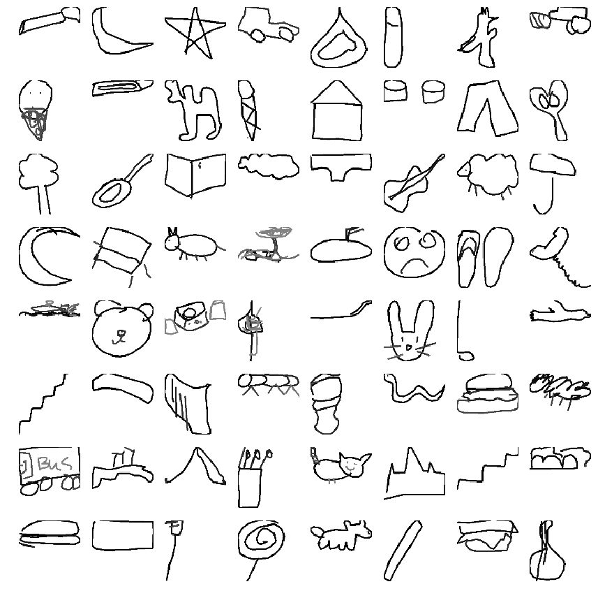

```python
train_datagen = image_generator_xd(size=size, batchsize=batchsize, ks=range(NCSVS - 1))
x, y = next(train_datagen)
n = 8
fig, axs = plt.subplots(nrows=n, ncols=n, sharex=True, sharey=True, figsize=(12, 12))
for i in range(n**2):
    ax = axs[i // n, i % n]
    (-x[i]+1)/2
    ax.imshow((-x[i, :, :, 0] + 1)/2, cmap=plt.cm.gray)
    ax.axis('off')
plt.tight_layout()
fig.savefig('gs.png', dpi=300)
plt.show();
```

```python
BestModelWeightsPath = './BestModel.hdf5'
callbacks = [
    ReduceLROnPlateau(
        monitor='val_categorical_accuracy',
        factor=0.1, patience=4,
        min_delta=0.001,
        mode='max',
        cooldown=3,
        verbose=1
    ),
    EarlyStopping(
        monitor='val_loss',
        mode='min',
        patience=10
    ),
    ModelCheckpoint(
        BestModelWeightsPath, monitor='val_loss', verbose=1,
        save_best_only=True,
        save_weights_only=True,
        mode='min'
    )
]
hists = []
hist = model.fit_generator(
    train_datagen, steps_per_epoch=STEPS, epochs=EPOCHS, verbose=1,
    validation_data=(x_valid, y_valid),
    callbacks = callbacks
)
hists.append(hist)
```

```
Epoch 00001: val_loss improved from inf to 5.84994, saving model to ./BestModel.hdf5
Epoch 00002: val_loss did not improve from 5.84994
Epoch 00003: val_loss did not improve from 5.84994
Epoch 00004: val_loss did not improve from 5.84994
Epoch 00005: ReduceLROnPlateau reducing learning rate to 0.0009999999776482583.

Epoch 00005: val_loss did not improve from 5.84994
```

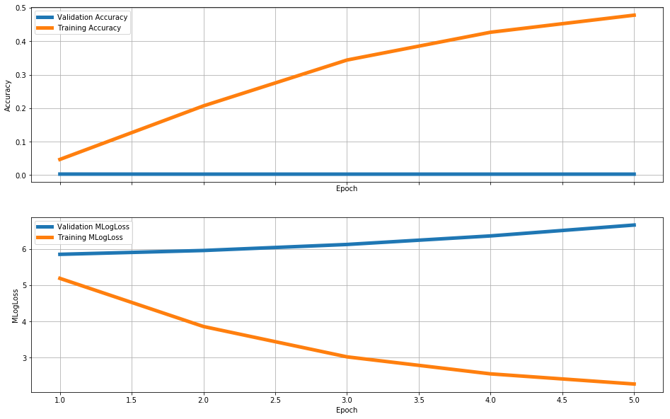

```python
hist_df = pd.concat([pd.DataFrame(hist.history) for hist in hists], sort=True)
hist_df.index = np.arange(1, len(hist_df)+1)
fig, axs = plt.subplots(nrows=2, sharex=True, figsize=(16, 10))
axs[0].plot(hist_df.val_categorical_accuracy, lw=5, label='Validation Accuracy')
axs[0].plot(hist_df.categorical_accuracy, lw=5, label='Training Accuracy')
axs[0].set_ylabel('Accuracy')
axs[0].set_xlabel('Epoch')
axs[0].grid()
axs[0].legend(loc=0)
axs[1].plot(hist_df.val_categorical_crossentropy, lw=5, label='Validation MLogLoss')
axs[1].plot(hist_df.categorical_crossentropy, lw=5, label='Training MLogLoss')
axs[1].set_ylabel('MLogLoss')
axs[1].set_xlabel('Epoch')
axs[1].grid()
axs[1].legend(loc=0)
fig.savefig('hist.png', dpi=300)
plt.show();
```

```python
# Load Best model weights
model.load_weights(BestModelWeightsPath)
valid_predictions = model.predict(x_valid, batch_size=128, verbose=1)
map3 = mapk(valid_df[['y']].values, preds2catids(valid_predictions).values)
print('Map3: {:.3f}'.format(map3))
```

```
<tensorflow.python.training.checkpointable.util.CheckpointLoadStatus at 0x7f89104fef28>
```

```
Map3: 0.005
```

## Create Submission

```python
test = pd.read_csv(os.path.join(INPUT_DIR, 'test_simplified.csv')); gc.collect();
test.head();
x_test = df_to_image_array_xd(test, size)
print(test.shape, x_test.shape)
print('Test array memory {:.2f} GB'.format(x_test.nbytes / 1024.**3 )); gc.collect();
```

```
(112199, 3) (112199, 82, 82, 1)
Test array memory 2.81 GB
```

```python
test_predictions = model.predict(x_test, batch_size=128, verbose=1)

top3 = preds2catids(test_predictions)
top3.head()
top3.shape

cats = list_all_categories()
id2cat = {k: cat.replace(' ', '_') for k, cat in enumerate(cats)}
top3cats = top3.replace(id2cat)
top3cats.head()
top3cats.shape
```

|  | a | b | c |
| --- | --- | --- | --- |
| 0 | 277 | 135 | 194 |
| 1 | 277 | 135 | 194 |
| 2 | 277 | 135 | 194 |
| 3 | 277 | 135 | 194 |
| 4 | 277 | 135 | 194 |

```
(112199, 3)
```

|  | a | b | c |
| --- | --- | --- | --- |
| 0 | squirrel | hammer | necklace |
| 1 | squirrel | hammer | necklace |
| 2 | squirrel | hammer | necklace |
| 3 | squirrel | hammer | necklace |
| 4 | squirrel | hammer | necklace |

```
(112199, 3)
```

```python
test['word'] = top3cats['a'] + ' ' + top3cats['b'] + ' ' + top3cats['c']
submission = test[['key_id', 'word']]
submission.to_csv('gs_mn_submission_{}.csv'.format(int(map3 * 10**4)), index=False)
submission.head()
submission.shape
```

|  | key_id | word |
| --- | --- | --- |
| 0 | 9000003627287624 | squirrel hammer necklace |
| 1 | 9000010688666847 | squirrel hammer necklace |
| 2 | 9000023642890129 | squirrel hammer necklace |
| 3 | 9000038588854897 | squirrel hammer necklace |
| 4 | 9000052667981386 | squirrel hammer necklace |

```
(112199, 2)
```

```python
end = dt.datetime.now()
print('Latest run {}.\nTotal time {}s'.format(end, (end - start).seconds))
```

```
Latest run 2018-12-01 11:44:51.557939.
Total time 4869s
```

## Comments:

- I've Organized some code in the way i like, and added **my** Shuffeled CSVs
- I'm trying to modify a kernel code that uses MobileNetV1, I wanted to use MobileNetV2 instead of V1, but i've got Memory error

## Recommendations:

- When using **CNN**, use: All training images, large images, correct network, large batch size, and train for many iterations. you you don't see improvement, change the way you render the strokes to images. (you have 3 channel rgb, make good use of it! try to encode more information)
- Memory Error solved after adding the prefix **tensorflow** in keras imports